# SR_01_DISREG_ENTITY_ADDR_STATE

Disregarded entity state · Code report

## Overview

**Description**

Province or state

**Table**

`SR-P01-T01-ID-DISREGARDED-ENTITIES` (many)

**Location code**

`SCHED-R-PART-01-COL-A`

**Family**

`SCHED-R-PART-01-COL-A` · siblings: SR_01_DISREG_ENTITY_ADDR_CITY, SR_01_DISREG_ENTITY_ADDR_CNTR, SR_01_DISREG_ENTITY_ADDR_L1, SR_01_DISREG_ENTITY_ADDR_L2, SR_01_DISREG_ENTITY_ADDR_ZIP, SR_01_DISREG_ENTITY_EIN

**Data type**

text (xsd: TextType, StateType)

**Scope**

PC

**Status**

unreviewed

6

xpaths mapped (6 observed)

116,204

filings with a value

2009–2024

tax years observed

4

open flags (1 errors)

## Flags

| Severity | Flag | Xpath | Detail |
| --- | --- | --- | --- |
| ⚠ error | `COLLISION` | IRS990ScheduleR/IdDisregardedEntitiesGrp/ForeignAddress/ProvinceOrStateNm | 411 filings contain 2+ of its xpaths; most common set: /Return/ReturnData/IRS990ScheduleR/IdDisregardedEntitiesGrp/ForeignAddress/ProvinceOrStateNm ; /Return/ReturnData/IRS990ScheduleR/IdDisregardedEn… |
| ⓘ info | `MANY_NOT_REPEATING` | IRS990ScheduleR/IdDisregardedEntitiesGrp/USAddress/StateAbbreviationCd | many-to-one table, but 58% of values sit in no repeating element |
| ⓘ info | `MANY_NOT_REPEATING` | IRS990ScheduleR/Form990ScheduleRPartI/AddressUS/State | many-to-one table, but 58% of values sit in no repeating element |
| ⓘ info | `MANY_NOT_REPEATING` | IRS990ScheduleR/IdDisregardedEntitiesGrp/USAddress/State | many-to-one table, but 58% of values sit in no repeating element |

## Xpaths

All mapped xpaths (under /Return/ReturnData or /Return/ReturnHeader), oldest first. Charts label each series by its xpath.

| Xpath | Form | Chart label | First year | Last year | Versions | Filings | Repeats in |
| --- | --- | --- | --- | --- | --- | --- | --- |
| IRS990ScheduleR/Form990ScheduleRPartI/AddressUS/State | Sched R | same | 2009 | 2012 | 17 | 15,198 | 41.7% |
| IRS990ScheduleR/Form990ScheduleRPartI/AddressForeign/ProvinceOrState | Sched R | …uleR/Form990ScheduleRPartI/AddressForeign/ProvinceOrState | 2009 | 2012 | 13 | 132 | 25.0% |
| IRS990ScheduleR/IdDisregardedEntitiesGrp/USAddress/State | Sched R | same | 2013 | 2013 | 3 | 5,674 | 41.6% |
| IRS990ScheduleR/IdDisregardedEntitiesGrp/ForeignAddress/ProvinceOrState | Sched R | …R/IdDisregardedEntitiesGrp/ForeignAddress/ProvinceOrState | 2013 | 2013 | 3 | 43 | 37.2% |
| IRS990ScheduleR/IdDisregardedEntitiesGrp/USAddress/StateAbbreviationCd | Sched R | …eR/IdDisregardedEntitiesGrp/USAddress/StateAbbreviationCd | 2014 | 2024 | 34 | 94,365 | 41.7% |
| IRS990ScheduleR/IdDisregardedEntitiesGrp/ForeignAddress/ProvinceOrStateNm | Sched R | …IdDisregardedEntitiesGrp/ForeignAddress/ProvinceOrStateNm | 2014 | 2024 | 32 | 792 | 30.4% |

## Coverage

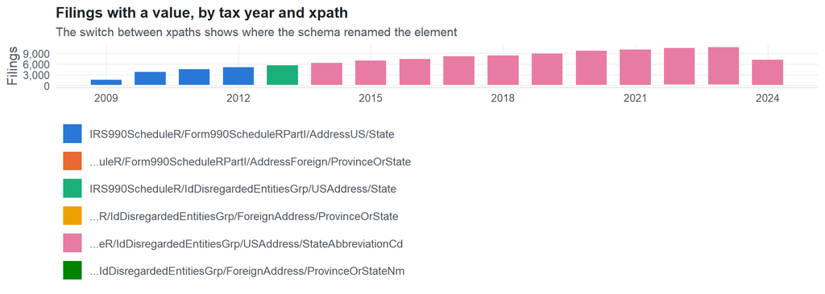

**Table view**

Table view: filings by tax year and series

| Tax year | IRS990ScheduleR/Form990ScheduleRPartI/AddressUS/State | …uleR/Form990ScheduleRPartI/AddressForeign/ProvinceOrState | IRS990ScheduleR/IdDisregardedEntitiesGrp/USAddress/State | …R/IdDisregardedEntitiesGrp/ForeignAddress/ProvinceOrState | …eR/IdDisregardedEntitiesGrp/USAddress/StateAbbreviationCd | …IdDisregardedEntitiesGrp/ForeignAddress/ProvinceOrStateNm |
| --- | --- | --- | --- | --- | --- | --- |
| 2009 | 1,642 | 22 | 0 | 0 | 0 | 0 |
| 2010 | 3,830 | 36 | 0 | 0 | 0 | 0 |
| 2011 | 4,569 | 37 | 0 | 0 | 0 | 0 |
| 2012 | 5,157 | 37 | 0 | 0 | 0 | 0 |
| 2013 | 0 | 0 | 5,674 | 43 | 0 | 0 |
| 2014 | 0 | 0 | 0 | 0 | 6,371 | 44 |
| 2015 | 0 | 0 | 0 | 0 | 6,972 | 52 |
| 2016 | 0 | 0 | 0 | 0 | 7,455 | 54 |
| 2017 | 0 | 0 | 0 | 0 | 8,214 | 60 |
| 2018 | 0 | 0 | 0 | 0 | 8,351 | 72 |
| 2019 | 0 | 0 | 0 | 0 | 8,893 | 76 |
| 2020 | 0 | 0 | 0 | 0 | 9,670 | 81 |
| 2021 | 0 | 0 | 0 | 0 | 10,045 | 83 |
| 2022 | 0 | 0 | 0 | 0 | 10,486 | 91 |
| 2023 | 0 | 0 | 0 | 0 | 10,704 | 103 |
| 2024 | 0 | 0 | 0 | 0 | 7,204 | 76 |

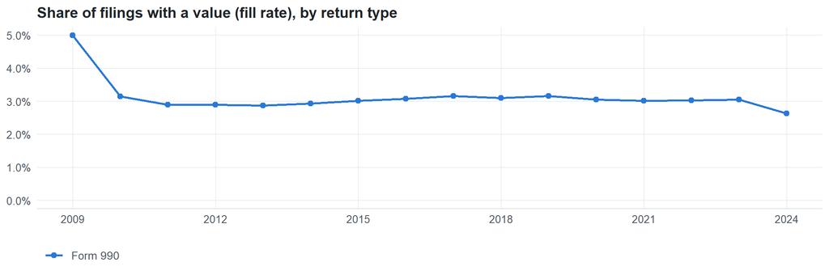

**Table view**

Table view: fill rate

| Tax year | Return type | Filings | All filings | Fill rate |
| --- | --- | --- | --- | --- |
| 2009 | Form 990 | 1,664 | 33,311 | 5.00% |
| 2010 | Form 990 | 3,866 | 123,025 | 3.14% |
| 2011 | Form 990 | 4,606 | 159,504 | 2.89% |
| 2012 | Form 990 | 5,194 | 179,688 | 2.89% |
| 2013 | Form 990 | 5,717 | 198,855 | 2.87% |
| 2014 | Form 990 | 6,415 | 218,619 | 2.93% |
| 2015 | Form 990 | 7,024 | 233,519 | 3.01% |
| 2016 | Form 990 | 7,509 | 243,903 | 3.08% |
| 2017 | Form 990 | 8,274 | 261,612 | 3.16% |
| 2018 | Form 990 | 8,423 | 271,442 | 3.10% |
| 2019 | Form 990 | 8,969 | 283,694 | 3.16% |
| 2020 | Form 990 | 9,751 | 320,342 | 3.04% |
| 2021 | Form 990 | 10,128 | 336,480 | 3.01% |
| 2022 | Form 990 | 10,577 | 349,055 | 3.03% |
| 2023 | Form 990 | 10,807 | 354,768 | 3.05% |
| 2024 | Form 990 | 7,280 | 277,298 | 2.63% |

## Repeating groups

Table cardinality in the concordance: **many**. 6 of 6 observed xpaths repeat within a filing.

Repeating element each xpath was observed in (from the raw indexed xpath)

| Xpath | Repeating element | Filings (summed over years) |
| --- | --- | --- |
| IRS990ScheduleR/Form990ScheduleRPartI/AddressForeign/ProvinceOrState | (none) | 39 |
| IRS990ScheduleR/Form990ScheduleRPartI/AddressForeign/ProvinceOrState | IRS990ScheduleR/Form990ScheduleRPartI | 93 |
| IRS990ScheduleR/Form990ScheduleRPartI/AddressUS/State | (none) | 8811 |
| IRS990ScheduleR/Form990ScheduleRPartI/AddressUS/State | IRS990ScheduleR/Form990ScheduleRPartI | 6387 |
| IRS990ScheduleR/IdDisregardedEntitiesGrp/ForeignAddress/ProvinceOrState | (none) | 12 |
| IRS990ScheduleR/IdDisregardedEntitiesGrp/ForeignAddress/ProvinceOrState | IRS990ScheduleR/IdDisregardedEntitiesGrp | 31 |
| IRS990ScheduleR/IdDisregardedEntitiesGrp/USAddress/State | (none) | 3283 |
| IRS990ScheduleR/IdDisregardedEntitiesGrp/USAddress/State | IRS990ScheduleR/IdDisregardedEntitiesGrp | 2391 |
| IRS990ScheduleR/IdDisregardedEntitiesGrp/ForeignAddress/ProvinceOrStateNm | (none) | 309 |
| IRS990ScheduleR/IdDisregardedEntitiesGrp/ForeignAddress/ProvinceOrStateNm | IRS990ScheduleR/IdDisregardedEntitiesGrp | 483 |
| IRS990ScheduleR/IdDisregardedEntitiesGrp/USAddress/StateAbbreviationCd | (none) | 54639 |
| IRS990ScheduleR/IdDisregardedEntitiesGrp/USAddress/StateAbbreviationCd | IRS990ScheduleR/IdDisregardedEntitiesGrp | 39726 |

## Values

| Result | Check | Detail |
| --- | --- | --- |
| ▲ warn | Small code list | up to 101 distinct values per xpath and year |
| ✓ pass | Codes share one format | 99% have the shape AA |
| ✓ pass | Consistent letter case | 0.0% of values are lower case |

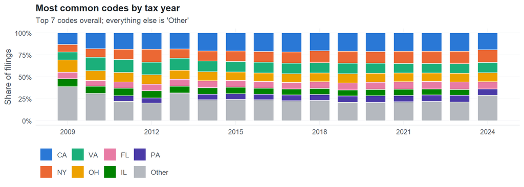

**Table view**

Table view: filings by code and tax year

| tax_year | CA | NY | VA | OH | FL | IL | PA | Other |
| --- | --- | --- | --- | --- | --- | --- | --- | --- |
| 2009 | 129 | 83 | 88 | 137 | 70 | 89 | 0 | 375 |
| 2010 | 374 | 206 | 316 | 233 | 136 | 172 | 0 | 640 |
| 2011 | 454 | 276 | 361 | 255 | 177 | 206 | 151 | 531 |
| 2012 | 519 | 414 | 400 | 302 | 209 | 227 | 160 | 565 |
| 2013 | 582 | 338 | 427 | 331 | 251 | 242 | 0 | 997 |
| 2014 | 727 | 403 | 441 | 357 | 280 | 265 | 220 | 846 |
| 2015 | 809 | 464 | 459 | 379 | 293 | 291 | 254 | 940 |
| 2016 | 864 | 511 | 493 | 403 | 308 | 278 | 262 | 972 |
| 2017 | 973 | 573 | 529 | 445 | 328 | 302 | 286 | 1,014 |
| 2018 | 921 | 617 | 521 | 452 | 344 | 313 | 308 | 1,036 |
| 2019 | 974 | 630 | 556 | 483 | 366 | 321 | 334 | 969 |
| 2020 | 1,063 | 675 | 566 | 511 | 414 | 363 | 383 | 1,034 |
| 2021 | 1,108 | 721 | 569 | 522 | 446 | 375 | 376 | 1,134 |
| 2022 | 1,147 | 766 | 595 | 543 | 462 | 384 | 406 | 1,195 |
| 2023 | 1,164 | 784 | 597 | 556 | 474 | 359 | 425 | 1,183 |
| 2024 | 719 | 543 | 438 | 384 | 317 | 0 | 262 | 1,085 |

Code frequencies (all xpaths, all years)

| Code | Filings | Share |
| --- | --- | --- |
| CA | 12,527 | 20.3% |
| NY | 8,004 | 13.0% |
| VA | 7,356 | 11.9% |
| OH | 6,293 | 10.2% |
| FL | 4,875 | 7.9% |
| IL | 4,187 | 6.8% |
| PA | 3,827 | 6.2% |
| MD | 3,319 | 5.4% |
| TX | 2,784 | 4.5% |
| MN | 2,669 | 4.3% |
| MI | 1,900 | 3.1% |
| MA | 1,518 | 2.5% |
| GA | 827 | 1.3% |
| IN | 367 | 0.6% |
| NC | 295 | 0.5% |
| CO | 236 | 0.4% |
| OR | 88 | 0.1% |
| LONDON | 58 | 0.1% |
| England | 56 | 0.1% |
| ENGLAND | 38 | 0.1% |
| GRAND CAYMAN | 31 | 0.1% |
| ONTARIO | 30 | 0.0% |
| NSW | 24 | 0.0% |
| BEIJING | 21 | 0.0% |
| NAIROBI | 21 | 0.0% |
| LUSAKA | 21 | 0.0% |
| MASERU | 21 | 0.0% |
| HONG KONG | 20 | 0.0% |
| KYIV | 20 | 0.0% |
| Fira Barcelona | 18 | 0.0% |

First rows shown.

## Examples

| Tax year | Return | Xpath | Organization | Value | Source |
| --- | --- | --- | --- | --- | --- |
| 2024 | 990 | IRS990ScheduleR/IdDisregardedEntitiesGrp/ForeignAddress/ProvinceOrStateNm | NRECA INTERNATIONAL | VICTORIA ISLAND | [XML](https://gt990datalake-rawdata.s3.amazonaws.com/EfileData/XmlFiles/202513219349325546_public.xml) |
| 2024 | 990 | IRS990ScheduleR/IdDisregardedEntitiesGrp/USAddress/StateAbbreviationCd | THE CLEVELAND CLINIC FOUNDATION | OH | [XML](https://gt990datalake-rawdata.s3.amazonaws.com/EfileData/XmlFiles/202513189349302136_public.xml) |
| 2023 | 990 | IRS990ScheduleR/IdDisregardedEntitiesGrp/ForeignAddress/ProvinceOrStateNm | 100 WOMEN IN FINANCE FOUNDATION | CAUSEWAY BAY | [XML](https://gt990datalake-rawdata.s3.amazonaws.com/EfileData/XmlFiles/202403179349303650_public.xml) |
| 2023 | 990 | IRS990ScheduleR/IdDisregardedEntitiesGrp/USAddress/StateAbbreviationCd | ARH TUG VALLEY HEALTH SERVICES INC | KY | [XML](https://gt990datalake-rawdata.s3.amazonaws.com/EfileData/XmlFiles/202511349349306946_public.xml) |
| 2022 | 990 | IRS990ScheduleR/IdDisregardedEntitiesGrp/ForeignAddress/ProvinceOrStateNm | SPORTSMEN FOR FISH & WILDLIFE INC | BC | [XML](https://gt990datalake-rawdata.s3.amazonaws.com/EfileData/XmlFiles/202503219349323605_public.xml) |
| 2022 | 990 | IRS990ScheduleR/IdDisregardedEntitiesGrp/USAddress/StateAbbreviationCd | SUN MINISTRIES INC | MO | [XML](https://gt990datalake-rawdata.s3.amazonaws.com/EfileData/XmlFiles/202313199349304366_public.xml) |
| 2021 | 990 | IRS990ScheduleR/IdDisregardedEntitiesGrp/ForeignAddress/ProvinceOrStateNm | CHARITIES AID FOUNDATION AMERICA | KENT | [XML](https://gt990datalake-rawdata.s3.amazonaws.com/EfileData/XmlFiles/202320699349300532_public.xml) |
| 2021 | 990 | IRS990ScheduleR/IdDisregardedEntitiesGrp/USAddress/StateAbbreviationCd | REGIONAL HOUSING & COMMUNITY SVC CORP | GA | [XML](https://gt990datalake-rawdata.s3.amazonaws.com/EfileData/XmlFiles/202303059349300430_public.xml) |
| 2020 | 990 | IRS990ScheduleR/IdDisregardedEntitiesGrp/ForeignAddress/ProvinceOrStateNm | GLOBAL BUSINESS TRAVEL ASSOCIATION | NAUCALPAN | [XML](https://gt990datalake-rawdata.s3.amazonaws.com/EfileData/XmlFiles/202113199349321271_public.xml) |
| 2020 | 990 | IRS990ScheduleR/IdDisregardedEntitiesGrp/USAddress/StateAbbreviationCd | ORLANDO REGIONAL REALTOR ASSOCIATION | FL | [XML](https://gt990datalake-rawdata.s3.amazonaws.com/EfileData/XmlFiles/202113199349304396_public.xml) |
| 2019 | 990 | IRS990ScheduleR/IdDisregardedEntitiesGrp/ForeignAddress/ProvinceOrStateNm | Diabetes Research Institute Foundation Inc | England | [XML](https://gt990datalake-rawdata.s3.amazonaws.com/EfileData/XmlFiles/202130909349300813_public.xml) |
| 2019 | 990 | IRS990ScheduleR/IdDisregardedEntitiesGrp/USAddress/StateAbbreviationCd | NOSOTROS INC | AZ | [XML](https://gt990datalake-rawdata.s3.amazonaws.com/EfileData/XmlFiles/202141269349301229_public.xml) |

## Reviewer checklist

- The definition matches the form line and instructions for every xpath’s schema years.
- Every xpath pooled here measures the same thing on the 990 and 990-EZ (close enough for analysis).
- The coverage chart has no unexplained gaps or jumps between tax years.
- Each open flag is fixed, or accepted with a note in validation_log.csv.
- Every code is valid for the list the form uses (state, country, valuation method, …).
- The code list and its meaning did not change across schema versions.
- Codes are stored as text, so values like leading zeros are preserved.

Record the review as a row in `inst/extdata/src/validation_log.csv` (variable_name, reviewer, date, status, note). Evidence built 2026-09-23 17:09:04 MST from the ef2 DuckDB builds (tax years 2009–2024).